# Breast Cancer Prediction

Mansour Alhumaid

28 Nov 2020

Data From: https://archive.ics.uci.edu/ml/datasets/Breast+Cancer+Coimbra

#### EDA

as start on the exploration process on the data, to explore available features and observations of each:

```
## [1] 116
```

```
## [1] 10
```

```
##   Age      BMI Glucose Insulin      HOMA  Leptin Adiponectin Resistin   MCP.1
## 1  48 23.50000      70   2.707 0.4674087  8.8071    9.702400  7.99585 417.114
## 2  83 20.69049      92   3.115 0.7068973  8.8438    5.429285  4.06405 468.786
## 3  82 23.12467      91   4.498 1.0096511 17.9393   22.432040  9.27715 554.697
## 4  68 21.36752      77   3.226 0.6127249  9.8827    7.169560 12.76600 928.220
## 5  86 21.11111      92   3.549 0.8053864  6.6994    4.819240 10.57635 773.920
## 6  49 22.85446      92   3.226 0.7320869  6.8317   13.679750 10.31760 530.410
##   Classification
## 1              1
## 2              1
## 3              1
## 4              1
## 5              1
## 6              1
```

```
##     Age   BMI Glucose Insulin     HOMA Leptin Adiponectin Resistin  MCP.1
## 111  54 36.05     119   11.91 3.495982  89.27        8.01     5.06 218.28
## 112  45 26.85      92    3.33 0.755688  54.68       12.10    10.96 268.23
## 113  62 26.84     100    4.53 1.117400  12.45       21.42     7.32 330.16
## 114  65 32.05      97    5.73 1.370998  61.48       22.54    10.33 314.05
## 115  72 25.59      82    2.82 0.570392  24.96       33.75     3.27 392.46
## 116  86 27.18     138   19.91 6.777364  90.28       14.11     4.35  90.09
##     Classification
## 111              2
## 112              2
## 113              2
## 114              2
## 115              2
## 116              2
```

```
## 'data.frame':    116 obs. of  10 variables:
##  $ Age           : int  48 83 82 68 86 49 89 76 73 75 ...
##  $ BMI           : num  23.5 20.7 23.1 21.4 21.1 ...
##  $ Glucose       : int  70 92 91 77 92 92 77 118 97 83 ...
##  $ Insulin       : num  2.71 3.12 4.5 3.23 3.55 ...
##  $ HOMA          : num  0.467 0.707 1.01 0.613 0.805 ...
##  $ Leptin        : num  8.81 8.84 17.94 9.88 6.7 ...
##  $ Adiponectin   : num  9.7 5.43 22.43 7.17 4.82 ...
##  $ Resistin      : num  8 4.06 9.28 12.77 10.58 ...
##  $ MCP.1         : num  417 469 555 928 774 ...
##  $ Classification: int  1 1 1 1 1 1 1 1 1 1 ...
```

#### Conversion

#### finding null values

```
## integer(0)
```

```
## [1] FALSE
```

#### Visualization

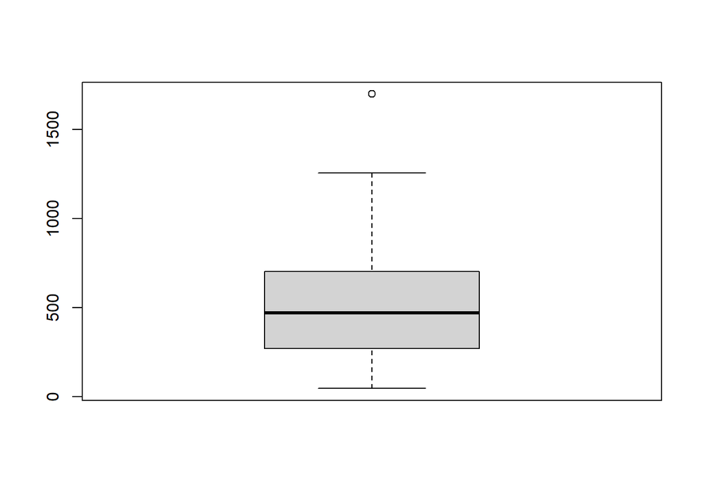

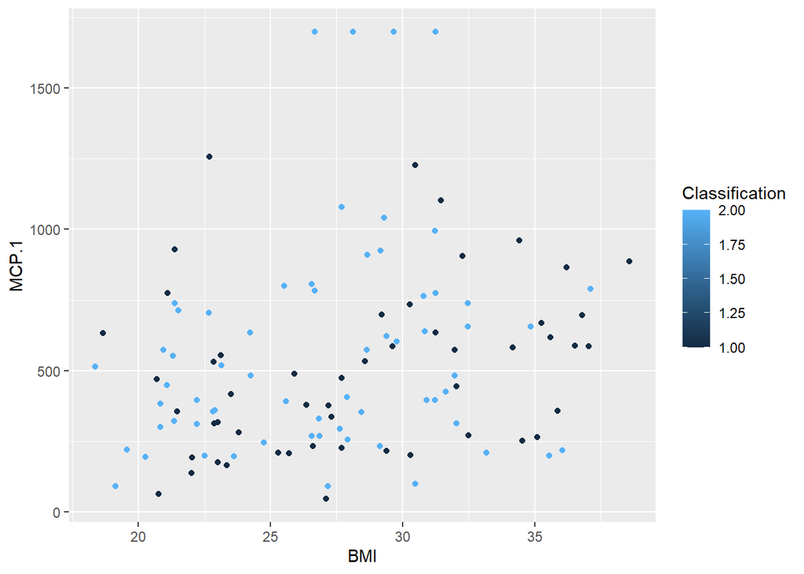

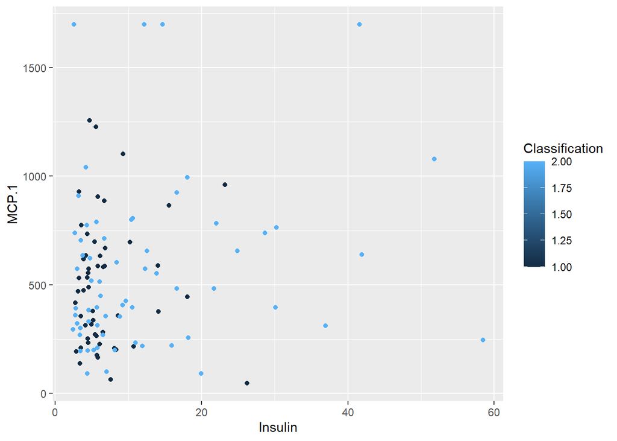

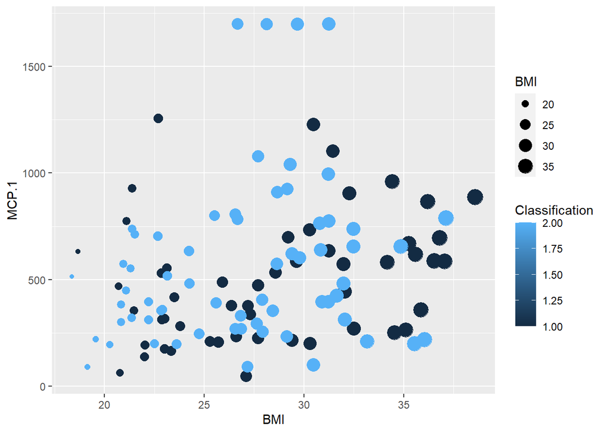

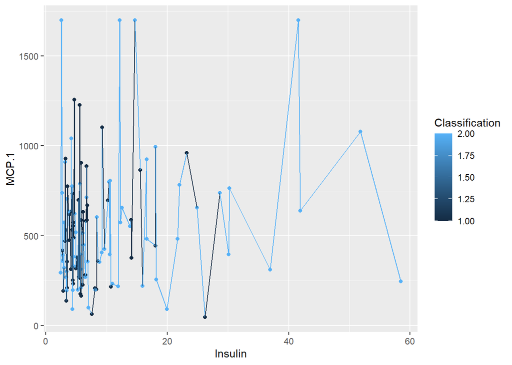

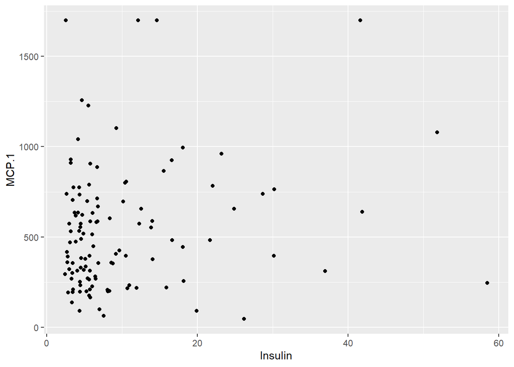

#### observations:

If the insulin is in the range of 0-20 , MCP-1 is ranging in between 230 -1050 then there is a chance that the person can get breast cancer

#### mapping vs setting

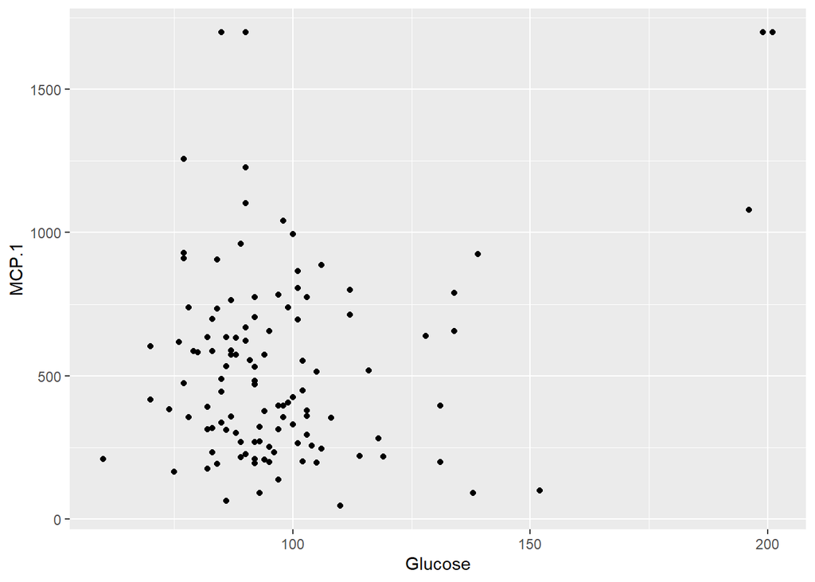

#### Finding correlation

when we have various variables,Correlation is an important factor to check the dependencies within themselves its gives us an insight between mutual relationship among variables to get correlation among different variables for a data set use following

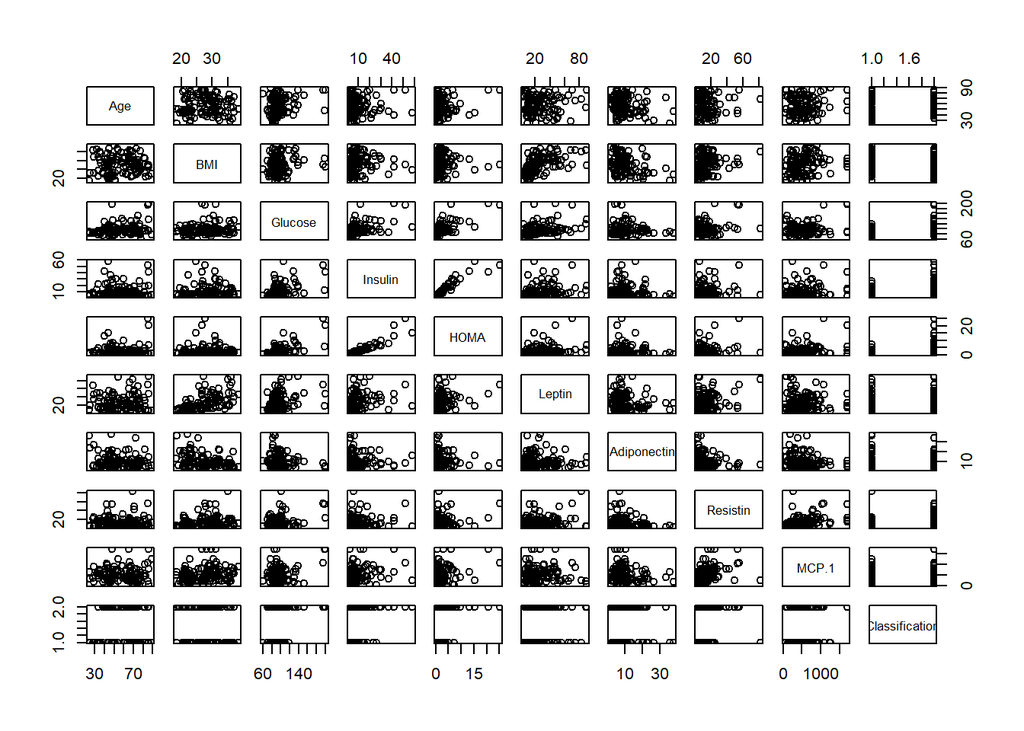

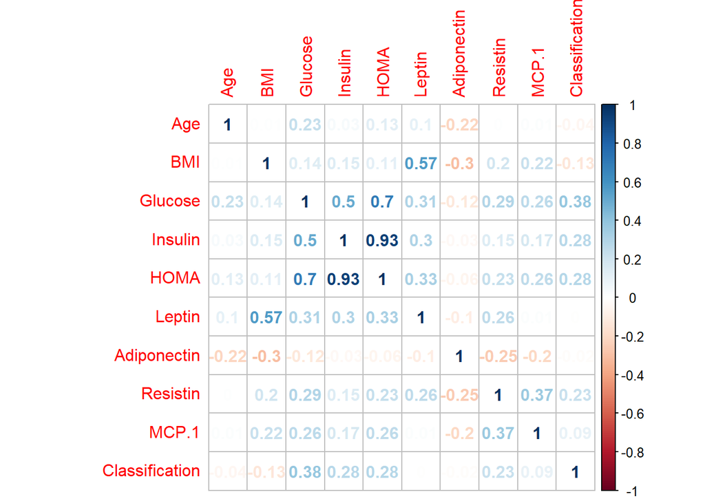

#### Multicollinearity

Multicollinearity makes it hard to interpret your coefficients, and it reduces the power of your model to identify independent variables that are statistically significant.

These are problems need to be overcome by using different ML concepts

```
##            Age            BMI        Glucose        Insulin           HOMA
##       1.354546       2.100892       4.151507      14.871457      22.732238
##         Leptin    Adiponectin       Resistin Classification
##       1.899414       1.251293       1.428484       1.471561
```

Now create the model

```
##
## Call:
## lm(formula = MCP.1 ~ ., data = train)
##
## Residuals:
##     Min      1Q  Median      3Q     Max
## -472.01 -182.41   -5.23  160.59 1089.08
##
## Coefficients:
##                 Estimate Std. Error t value Pr(>|t|)
## (Intercept)    -155.9415   377.3210  -0.413  0.68064
## Age               0.2624     2.3897   0.110  0.91287
## BMI              23.3618     9.3763   2.492  0.01506 *
## Glucose           1.4299     2.7679   0.517  0.60704
## Insulin         -22.9808    13.3678  -1.719  0.08995 .
## HOMA             70.8435    39.7999   1.780  0.07936 .
## Leptin           -5.1793     2.4152  -2.144  0.03542 *
## Adiponectin      -3.5942     6.9424  -0.518  0.60626
## Resistin         10.0330     3.4614   2.899  0.00498 **
## Classification  -29.5265    78.9990  -0.374  0.70970
## ---
## Signif. codes:  0 '***' 0.001 '**' 0.01 '*' 0.05 '.' 0.1 ' ' 1
##
## Residual standard error: 293 on 71 degrees of freedom
## Multiple R-squared:  0.3715, Adjusted R-squared:  0.2918
## F-statistic: 4.663 on 9 and 71 DF,  p-value: 7.25e-05
```

from summary we came to know there is less correaltion between all columns related to target column

```
##
## Call:
## lm(formula = MCP.1 ~ BMI + Resistin + Glucose + HOMA + Insulin +
##     Leptin, data = train)
##
## Residuals:
##     Min      1Q  Median      3Q     Max
## -453.54 -200.37  -16.85  137.76 1065.49
##
## Coefficients:
##             Estimate Std. Error t value Pr(>|t|)
## (Intercept) -231.442    272.048  -0.851  0.39766
## BMI           24.750      8.666   2.856  0.00556 **
## Resistin       9.829      3.147   3.124  0.00255 **
## Glucose        1.208      2.537   0.476  0.63547
## HOMA          73.792     37.970   1.943  0.05577 .
## Insulin      -23.935     12.810  -1.868  0.06566 .
## Leptin        -5.122      2.369  -2.162  0.03387 *
## ---
## Signif. codes:  0 '***' 0.001 '**' 0.01 '*' 0.05 '.' 0.1 ' ' 1
##
## Residual standard error: 288 on 74 degrees of freedom
## Multiple R-squared:  0.3672, Adjusted R-squared:  0.3159
## F-statistic: 7.156 on 6 and 74 DF,  p-value: 4.858e-06
```

```
##        11        14        17        22        25        26        36        38
##  353.7502  310.7326  286.2492  536.3588  626.9095  606.5376  470.2946 1107.1671
##        40        43        48        49        56        61        62        64
##  760.0153  524.1518  433.4012  333.5452  356.5378  516.6560  400.0119  517.8478
##        65        69        70        72        74        75        80        82
##  414.4962  430.6641  318.1501  196.7450  394.4634  119.9842  452.1083  708.7715
##        83        84        86        92        96       104       109       110
##  385.7668  820.8089  536.9713  592.3014  437.3062  501.1338  755.7852  589.1637
##       114       115       116
##  429.6147  379.8319  211.8648
```

#### Comparing Predicted vs Actual

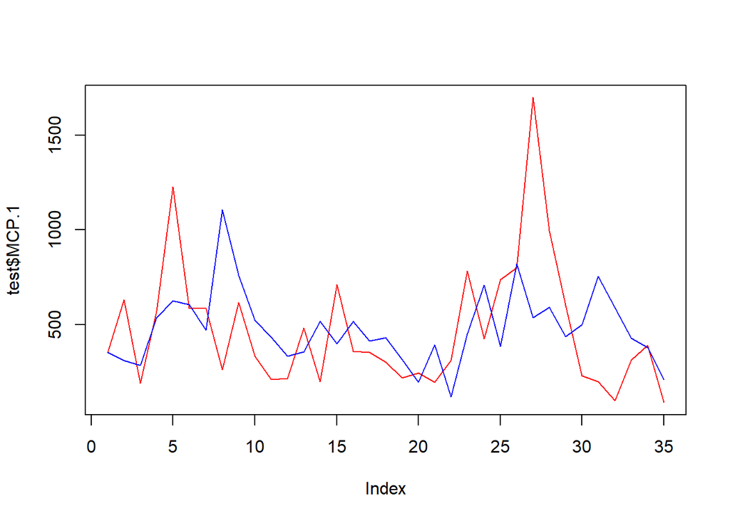

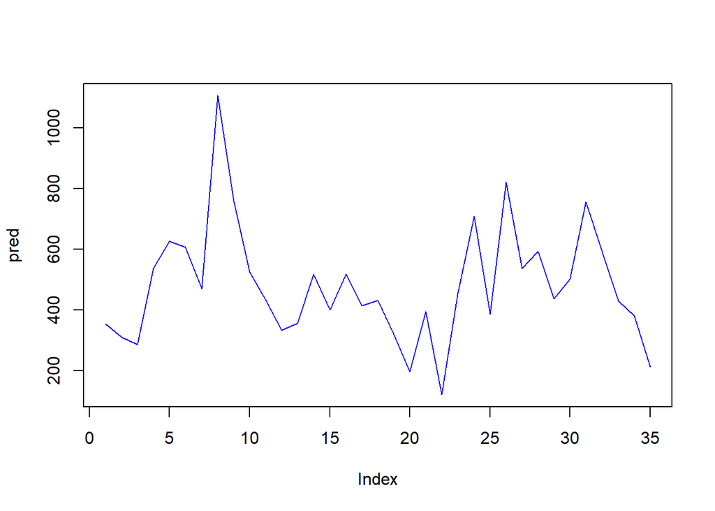

from this graph, prediction is not correlated with actual

#### Finding Accuracy

#### converting categorical into binary features

#### Model split

#### model building

```
##
## Call:
## glm(formula = Classification ~ ., family = "binomial", data = train)
##
## Deviance Residuals:
##      Min        1Q    Median        3Q       Max
## -2.11736  -0.62873   0.07366   0.69160   1.86828
##
## Coefficients:
##               Estimate Std. Error z value Pr(>|z|)
## (Intercept) -7.0083597  4.5727922  -1.533  0.12537
## Age         -0.0532258  0.0233389  -2.281  0.02257 *
## BMI         -0.1676682  0.0884052  -1.897  0.05788 .
## Glucose      0.1360032  0.0499808   2.721  0.00651 **
## Insulin      0.1032882  0.3834664   0.269  0.78766
## HOMA        -0.3183400  1.5921311  -0.200  0.84152
## Leptin      -0.0184409  0.0222546  -0.829  0.40731
## Adiponectin  0.0250136  0.0626149   0.399  0.68954
## Resistin     0.1403132  0.0523755   2.679  0.00738 **
## MCP.1        0.0003133  0.0010897   0.288  0.77371
## ---
## Signif. codes:  0 '***' 0.001 '**' 0.01 '*' 0.05 '.' 0.1 ' ' 1
##
## (Dispersion parameter for binomial family taken to be 1)
##
##     Null deviance: 111.288  on 80  degrees of freedom
## Residual deviance:  68.641  on 71  degrees of freedom
## AIC: 88.641
##
## Number of Fisher Scoring iterations: 8
```

#### predictions

```
##           3          11          12          13          14          17
## 0.264078018 0.372274731 0.418739353 0.543371699 0.934440960 0.335159505
##          21          22          25          26          36          38
## 0.383139314 0.173836970 0.322620553 0.036121925 0.015835191 0.999468697
##          40          43          48          49          61          62
## 0.015504667 0.067502050 0.002060786 0.044238035 0.924277479 0.951463170
##          64          65          69          70          72          74
## 0.911199129 0.651479986 0.795697854 0.983357425 0.951653676 0.587661357
##          75          80          84          86          92          96
## 0.687405729 0.977926215 0.998275533 0.403647172 0.553777101 0.094595630
##         104         110         114         115         116
## 0.091130521 0.995704504 0.180022331 0.051977289 0.864255718
```

#### confusion matrix

```
##            PredictedValue
## ActualValue FALSE TRUE
##           0    13    3
##           1     5   14
```

## Decision Tree

#### Model Building

```
## n= 81
##
## node), split, n, loss, yval, (yprob)
##       * denotes terminal node
##
##  1) root 81 36 1 (0.44444444 0.55555556)
##    2) Glucose< 87.5 21  5 0 (0.76190476 0.23809524)
##      4) HOMA>=0.8390145 14  1 0 (0.92857143 0.07142857) *
##      5) HOMA< 0.8390145 7  3 1 (0.42857143 0.57142857) *
##    3) Glucose>=87.5 60 20 1 (0.33333333 0.66666667)
##      6) Age>=65.5 23 10 0 (0.56521739 0.43478261)
##       12) Resistin< 12.7652 13  2 0 (0.84615385 0.15384615) *
##       13) Resistin>=12.7652 10  2 1 (0.20000000 0.80000000) *
##      7) Age< 65.5 37  7 1 (0.18918919 0.81081081)
##       14) BMI>=33.80109 7  2 0 (0.71428571 0.28571429) *
##       15) BMI< 33.80109 30  2 1 (0.06666667 0.93333333) *
```

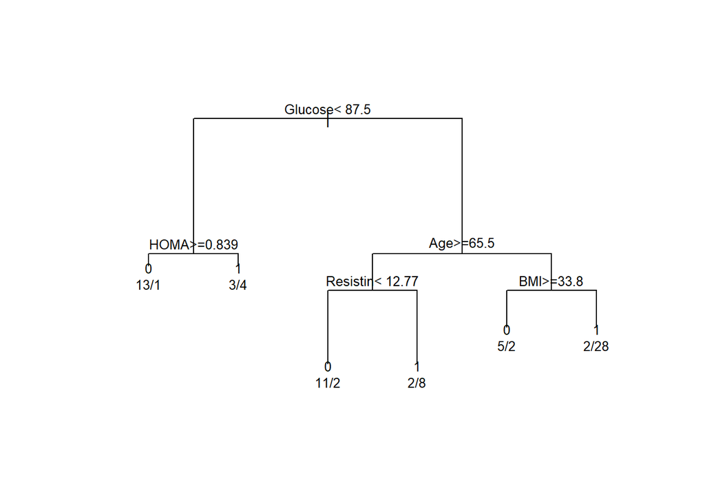

#### Predictions

```
##   3  11  12  13  14  17  21  22  25  26  36  38  40  43  48  49  61  62  64  65
##   0   1   0   1   1   1   0   0   1   0   0   1   1   0   1   0   1   1   1   1
##  69  70  72  74  75  80  84  86  92  96 104 110 114 115 116
##   1   1   1   0   0   1   1   0   1   0   0   0   1   1   0
## Levels: 0 1
```

#### Confusion matrix for evaluating the model

```
## Confusion Matrix and Statistics
##
##           Reference
## Prediction  0  1
##          0  8  7
##          1  8 12
##
##                Accuracy : 0.5714
##                  95% CI : (0.3935, 0.7368)
##     No Information Rate : 0.5429
##     P-Value [Acc > NIR] : 0.4347
##
##                   Kappa : 0.1322
##
##  Mcnemar's Test P-Value : 1.0000
##
##             Sensitivity : 0.5000
##             Specificity : 0.6316
##          Pos Pred Value : 0.5333
##          Neg Pred Value : 0.6000
##              Prevalence : 0.4571
##          Detection Rate : 0.2286
##    Detection Prevalence : 0.4286
##       Balanced Accuracy : 0.5658
##
##        'Positive' Class : 0
##
```

Sensitivity shows actual positive cases, while specialty shows negative values

## Random Forest

This method works in regression and classification

```
##
## Call:
##  randomForest(formula = Classification ~ ., data = train)
##                Type of random forest: classification
##                      Number of trees: 500
## No. of variables tried at each split: 3
##
##         OOB estimate of  error rate: 34.57%
## Confusion matrix:
##    0  1 class.error
## 0 21 15   0.4166667
## 1 13 32   0.2888889
```

```
##             MeanDecreaseGini
## Age                 6.396935
## BMI                 4.532691
## Glucose             7.365476
## Insulin             2.850436
## HOMA                3.487127
## Leptin              3.907214
## Adiponectin         2.872104
## Resistin            5.328530
## MCP.1               2.777611
```

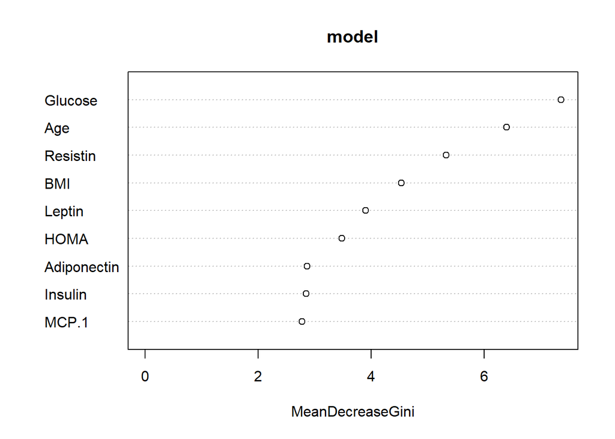

```
##   3  11  12  13  14  17  21  22  25  26  36  38  40  43  48  49  61  62  64  65
##   0   0   0   0   1   0   0   0   1   0   0   0   0   0   0   0   1   1   1   1
##  69  70  72  74  75  80  84  86  92  96 104 110 114 115 116
##   1   1   1   0   1   1   1   0   1   0   0   0   1   0   0
## Levels: 0 1
```

## KNN

Using Of KNN data Should be Labeled (structured format) Data Should be Noise free data should be small because KNN is lazy learner According to Ecludian distance we can calculate distance then we can say how many observations are similar based on their distance

K-Nearest Neighbor also known as KNN is a supervised learning algorithm that can be used for regression as well as classification problems. KNN is widely used for classification problems in machine learning. KNN works on a principle assuming every data point falling near to each other is falling in the same class. That means similar things are near to each other.

KNN algorithms decide a number k which is the nearest Neighbor to that data point which is to be classified. If the value of k is 5 it will look for 5 nearest Neighbors to that data point. lets the example, k=4. KNN finds out 4 nearest Neighbors. It is seen that because that data point is close to these Neighbors so it will belong to this class only.

#### What is the significance of k?

For getting the class which is to be predicted, repeat starting from 1 to the total number of training points we have.

The next step is to calculate the distance between the data point whose class is to be predicted and all the training data points. Euclidean distance can be used here.

Then, Arrange the distances in non-decreasing order.

Then, assume the positive value of k and filtering k lowest values from the sorted list.

Then, Normalize the data because by doing this we can get all observations similar format

```
##         Age       BMI    Glucose    Insulin        HOMA     Leptin Adiponectin
## 1 0.3692308 0.2538503 0.07092199 0.00490826 0.000000000 0.05229908  0.22115173
## 2 0.9076923 0.1148262 0.22695035 0.01219033 0.009742070 0.05272598  0.10370677
## 3 0.8923077 0.2352777 0.21985816 0.03687442 0.022057677 0.15852575  0.57102109
## 4 0.6769231 0.1483278 0.12056738 0.01417149 0.005911266 0.06481057  0.15153757
## 5 0.9538462 0.1356398 0.22695035 0.01993646 0.013748471 0.02778211  0.08693991
## 6 0.3846154 0.2219066 0.22695035 0.01417149 0.010766749 0.02932103  0.33046769
##     Resistin     MCP.1
## 1 0.06066485 0.2246591
## 2 0.01082583 0.2559263
## 3 0.07690645 0.3079117
## 4 0.12113069 0.5339336
## 5 0.09337495 0.4405654
## 6 0.09009507 0.2932155
```

#### Model splitting

#### Now creating a separate data frame for ‘Classification’ feature which is our target:

```
## [1] 81
```

#### Optimization of K value

```
## 1 = 60
## 2 = 48.57143
## 3 = 51.42857
## 4 = 51.42857
## 5 = 62.85714
## 6 = 45.71429
## 7 = 40
## 8 = 45.71429
## 9 = 34.28571
## 10 = 42.85714
## 11 = 40
## 12 = 40
## 13 = 37.14286
## 14 = 37.14286
## 15 = 42.85714
## 16 = 40
## 17 = 40
## 18 = 42.85714
## 19 = 40
## 20 = 40
## 21 = 40
## 22 = 40
## 23 = 40
## 24 = 40
## 25 = 40
## 26 = 40
## 27 = 40
## 28 = 40
```

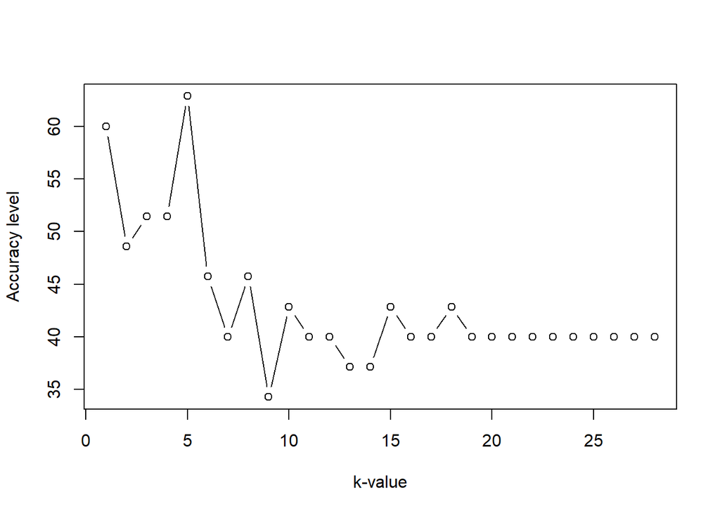

```
## [1] 68.57143
```

It is clear that K=5 has the highest accuracy among this trial (Knn 1~28)

#### To check predictions against actual value in tabular form

```
##      test.class_labels
## knn.2  0  1
##     0 11  1
##     1 10 13
```

## MARS

Many of these models can be adapted to nonlinear patterns in the data by manually adding model terms (i.e. squared terms, interaction effects);however, to do so you must know the specific nature of the non-linearity a prioriy. Alternatively, there are numerous algorithms that are inherently nonlinear.

When using these models, the exact form of the nonlinearity does not need to be known explicitly or specified prior to model training.

Rather, these algorithms will search for, and discover, nonlinearities in the data that help maximize predictive accuracy.

#### Fit a basic MARS model

```
## Selected 7 of 19 terms, and 5 of 9 predictors
## Termination condition: Reached nk 21
## Importance: Resistin, Glucose, Leptin, BMI, Age, Insulin-unused, ...
## Number of terms at each degree of interaction: 1 6 (additive model)
## GCV 81391.68    RSS 7443830    GRSq 0.3256476    RSq 0.4590393
```

```
## Selected 7 of 19 terms, and 5 of 9 predictors
## Termination condition: Reached nk 21
## Importance: Resistin, Glucose, Leptin, BMI, Age, Insulin-unused, ...
## Number of terms at each degree of interaction: 1 6 (additive model)
## GCV 81391.68    RSS 7443830    GRSq 0.3256476    RSq 0.4590393
```

```
##                          MCP.1
## (Intercept)         892.227689
## h(20.2535-Resistin) -19.394868
## h(Glucose-128)        9.938444
## h(Leptin-31.2128)    -8.608693
## h(35.2508-BMI)      -19.942964
## h(Age-78)            74.060424
## h(Age-65)           -16.063517
```

The plot method for MARS model objects provide convenient performance and residual plots.

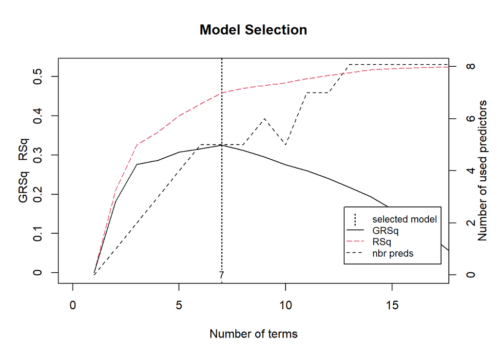

The model selection plot that graphs the GCV R2( generalized cross validation criterion. GCV is a form of regularization: it trades off goodness-of-fit against model complexity.)

(left-hand y-axis and solid black line) based on the number of terms retained in the model

(x-axis) which are constructed from a certain number of original predictors (right-hand y-axis).

#### Tuning

Since there are two tuning parameters associated with our MARS model: the degree of interactions and the number of retained terms, we need to perform a grid search to identify the optimal combination of these hyperparameters that minimize prediction error

##### create a tuning grid

```
##   degree nprune
## 1      1      2
## 2      2      2
## 3      3      2
## 4      1     12
## 5      2     12
## 6      3     12
```

We can use caret to perform a grid search using 10-fold cross-validation

#### cross validation model

#### best model

```
##   nprune degree
## 2     12      1
```

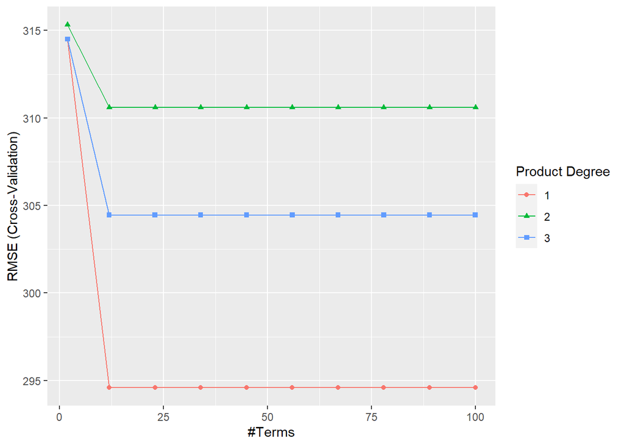

## Feature interpretation

MARS models via earth::earth() include a backwards elimination feature selection routine that looks at reductions in the Generalized Cross-Validation Statistic (GCV) estimate of error as each predictor is added to the model. This total reduction is used as the variable importance measure (value = “gcv”).

Since MARS will automatically include and exclude terms during the pruning process, it essentially performs automated feature selection. If a predictor was never used in any of the MARS basis functions in the final model (after pruning), it has an importance value of zero.

while the rest of the features have an importance value of zero since they were not included in the final model. Alternatively, you can also monitor the change in the residual sums of squares (RSS) as terms are added (value = “rss”);

however, very little difference between these two methods, as shown by below graphs:

#### variable importance plots

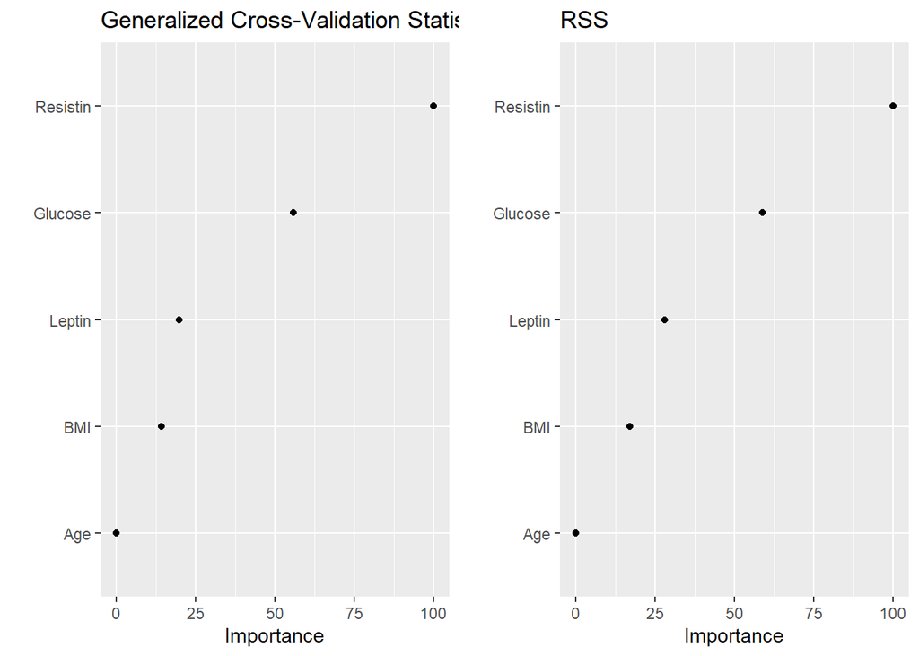

Its important to realize that variable importance will only measure the impact of the prediction error as features are included; however, it does not measure the impact for particular hinge functions created for a given feature.

For example, in Figure we see that Resistin and Glucose are the two most influential variables; however, variable importance does not tell us how our model is treating the non-linear patterns for each feature.

## Conclusion

MARS provides a great stepping stone into nonlinear modeling and tends to be fairly intuitive due to being closely related to multiple regression techniques. They are also easy to train and tune.